# Econometrics HW #1 Solutions

Ryan Safner

Due: Tuesday, September 25, 2018

Note: Answers may be longer than I would deem sufficient on an exam. Some might vary slightly based on points of interest, examples, or personal experience. These suggested answers are designed to give you both the answer and a short explanation of *why* it is the answer.

# Theory & Concepts

For the following questions, please answer the questions completely but succinctly (2-3 sentences).

### 1. Explain the difference between exogeneity and endogeneity.

An **exogenous** model is one where the independent variable ($X$) is not associated with any other factors that affect the dependent variable ($Y$). If a model is truly exogenous, we can estimate the **causal effect** of $X$ on $Y$.

An **endogenous** model is one where the independent variable ($X$) *is* associated with any other factors that affect the dependent variable ($Y$). If a model is endogenous, we have no accurately estimated the causal effect of $X$ on $Y$, since other factors are getting entangled with $X$ and $Y$.

### 2. Explain how conducting a randomized controlled experiment helps to identify the causal connection between two variables.

Randomized controlled experiments are where a pool of subjects representative of a population are randomly assigned into a treatment group (or into one of a number of groups given different levels of a treatment) or into a control group. The treatment group(s) is(are) given the treatment(s), the control group is given nothing (perhaps a placebo, though this is not always necessary), and then the average results of the two groups are compared to measure the true average effect of treatment.

The key is that the assignment must be random, which controls for all factors that potentially determine the outcome (e.g. when measuring individual outcomes, their height, family background, income, race, age, etc). If subjects are randomly assigned, then knowing anything about the individual (e.g. age, height, etc) tells us *nothing* about whether or not they got the treatment(s). The *only* thing that separates a member of the treatment group(s) from the control group is whether or not they were assigned to treatment. This ensures that the average person in the treatment group(s) looks like the average person in the control group, and that we are truly comparing apples to apples, rather than apples to oranges.

# Theory Problems

For the following questions, please *show all work* and explain answers as necessary. You may lose points if you only write the correct answer. You may use *R* to verify your answers, but you are expected to reach the answers in this section “manually.”

### 3. A college senior has applied for admission to two medical schools, *A* and *B*. She estimates the probability of acceptance at *A* at 0.7 and the probability of acceptance at *B* at 0.4 and the probability that she will be admitted to both at 0.2. What is the chance she will *not* be accepted at *either* school? (Consult the probability handout for basic probability rules.)

We are given $P(A)=0.7, P(B)=0.4,$ and $P(A\&B)=0.2$

Be careful, events A & B are *not* disjoint events! They can occur simultaneously, as you can get into multiple schools, so we must use the *general* addition rule of probability:

$$\begin{align*}
P(A\text{ or }B) &= P(A)+P(B)-P(\text{ and } B) \\
&=0.7+0.4-0.2\\
&=0.9\\
\end{align*}$$

$$P(A \text{ nor } B)= 1-0.9=0.1$$
There is thus a 10% chance that she gets into neither school.

### 4. Suppose the probabilities of a visitor to Amazon’s website and buying 0, 1, or 2 books are 0.2, 0.4, and 0.4 respectively. What are the *expected number* of books a visitor will purchase and the *standard deviation* of book purchases?

We first need to find the expected value:

$$\begin{align*}
\mu=E[X]&=\sum^n_{i=1} x_ip_i \\
E[X]&=0(0.2)+1(0.4)+2(0.4)\\
E[X]&=(0)+(0.4)+(0.8)\\
E[X]&=1.2
\end{align*}$$

Now we wanted the standard deviation of $X$, so we must square root the variance.

$$\begin{equation*}
\sigma=\sqrt{\sigma^2}=\sqrt{0.56}=0.748
\end{equation*}$$

So our findings are that people will, on average, buy 1.2 books with a standard deviation of 0.75 books.

### 5. Scores on the SAT (out of 1600) are approximately normally distributed with a mean of 500 and standard deviation of 100.

### a. What is the probability of getting a score between a 400 and a 600?

Let the random variable S be the SAT score. Then:

$$\begin{align*}
P(400 \leq S \leq 600)&=P\big(\frac{400-500}{100} \leq \frac{S - 500}{100} \leq \frac{600-500}{100}\big)\\
&=P\big(-1 \leq Z \leq 1\big)\\
&\approx 0.68\\
\end{align*}$$

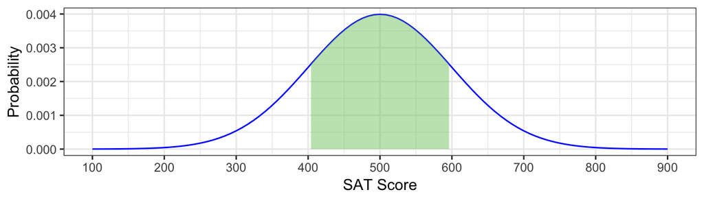

```r
# you do not need to draw the pdf graph
# I draw it only so you can visualize what you are estimating

# It is easy to draw a graph in ggplot2
# It requires a bit more effort to shade in specific areas
# which is why the code looks more complicated than it need be

# create shaded area for normal function with mean 500, sd 100
# between 400 and 600

shade.a <- function(x) {
    y <- dnorm(x, mean = 500, sd = 100)
    y[x < 400 | x >600] <- NA
    return(y)
}

# create the plot
library("ggplot2") # we'll need ggplot2 for this
ggplot(data.frame(x=100:900),aes(x=x))+  # let the data be some variable x between 100-900
    # draw normal pdf with mean 500, sd 500
    stat_function(fun=dnorm, args=list(mean=500, sd=100), color="blue")+
    # add the shaded function defined above
    stat_function(fun=shade.a, geom="area", fill="#84CA72", alpha=0.5)+
    # manually define the ticks on x axis as sequence from 100 to 900 by 100
    scale_x_continuous(breaks=seq(100,900,100))+
    xlab("SAT Score")+ylab("Probability")+theme_bw() # fix labels on graph
```

### b. What is the probability of getting a score between a 300 and a 700?

$$\begin{align*}
P(300 \leq S \leq 700)&=P\big(\frac{300-500}{100} \leq \frac{S - 500}{100} \leq \frac{700-500}{100}\big)\\
&=P\big(-2 \leq Z \leq 2\big)\\
&\approx 0.95\\
\end{align*}$$

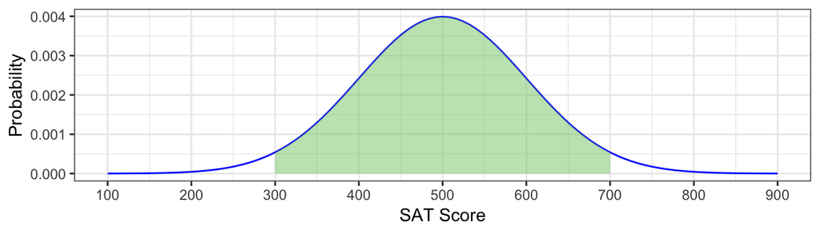

```r
# create shaded area for normal function with mean 500, sd 100
# between 300 and 700

shade.b <- function(x) {
    y <- dnorm(x, mean = 500, sd = 100)
    y[x < 300 | x >700] <- NA
    return(y)
}

# create the plot
ggplot(data.frame(x=100:900),aes(x=x))+
    stat_function(fun=dnorm, args=list(mean=500, sd=100), color="blue")+
    stat_function(fun=shade.b, geom="area", fill="#84CA72", alpha=0.5)+
    scale_x_continuous(breaks=seq(100,900,100))+
    xlab("SAT Score")+ylab("Probability")+theme_bw()
```

### c. What is the probability of getting *at least* a 700?

$$\begin{align*}
P(S \geq 700)&=P\big(\frac{S - 500}{100} \geq \frac{700-500}{100}\big)\\
&=P(Z \geq 2)\\
&\approx 0.025\\
\end{align*}$$

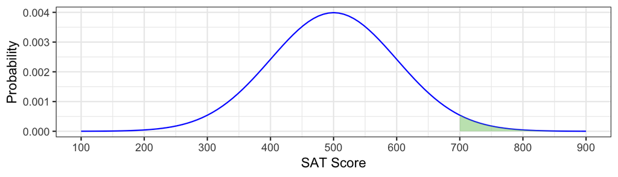

```r
# create shaded area for normal function with mean 500, sd 100
# between 700 and 900

shade.c <- function(x) {
    y <- dnorm(x, mean = 500, sd = 100)
    y[x < 700 | x >900] <- NA
    return(y)
}

# create the plot
ggplot(data.frame(x=100:900),aes(x=x))+
    stat_function(fun=dnorm, args=list(mean=500, sd=100), color="blue")+
    stat_function(fun=shade.c, geom="area", fill="#84CA72", alpha=0.5)+
    scale_x_continuous(breaks=seq(100,900,100))+
    xlab("SAT Score")+ylab("Probability")+theme_bw()
```

### d. What is the probability of getting *at most* a 700?

$$\begin{align*}
P(S \leq 700)&=P\big(\frac{S - 500}{100} \leq \frac{700-500}{100}\big)\\
&=P(Z \leq 2)\\
&\approx 0.975\\
\end{align*}$$

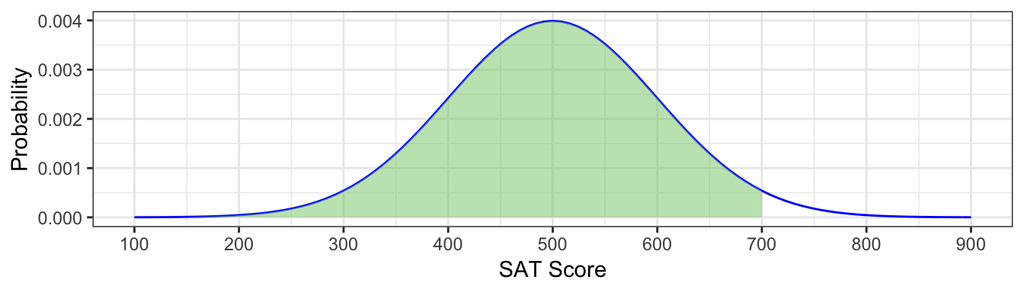

```r
# create shaded area for normal function with mean 500, sd 100
# between 100 and 700

shade.d <- function(x) {
    y <- dnorm(x, mean = 500, sd = 100)
    y[x < 100 | x >700] <- NA
    return(y)
}

# create the plot
ggplot(data.frame(x=100:900),aes(x=x))+
    stat_function(fun=dnorm, args=list(mean=500, sd=100), color="blue")+
    stat_function(fun=shade.d, geom="area", fill="#84CA72", alpha=0.5)+
    scale_x_continuous(breaks=seq(100,900,100))+
    xlab("SAT Score")+ylab("Probability")+theme_bw()
```

### e. What is the probability of getting exactly a 500?

This is a trick question to make sure you were paying attention about the pdf of a continuous variable. The probability of any particular value is so small, we define it as 0. We only can calculate the probability of a *range* of values. So

$$P(S=500)=0$$